# In-class Activity: Changing Baby Names Over Time

## Baby Names

The `babynames` package provides a data set (also called `babynames`) that we’re going to work with here. Let’s view the first 10 rows as usual:

| year | sex | name | n | prop |
| --- | --- | --- | --- | --- |
| 1880 | F | Mary | 7065 | 0.0723836 |
| 1880 | F | Anna | 2604 | 0.0266790 |
| 1880 | F | Emma | 2003 | 0.0205215 |
| 1880 | F | Elizabeth | 1939 | 0.0198658 |
| 1880 | F | Minnie | 1746 | 0.0178884 |
| 1880 | F | Margaret | 1578 | 0.0161672 |
| 1880 | F | Ida | 1472 | 0.0150812 |
| 1880 | F | Alice | 1414 | 0.0144870 |
| 1880 | F | Bertha | 1320 | 0.0135239 |
| 1880 | F | Sarah | 1288 | 0.0131961 |

Now, we’re going to attempt to filter the babynames dataset to get only names of people in this class. **Note the use of the `%in%` operator,** which is a convenient way of checking if some value belongs to a given set. It’s a cleaner alternative to something like `name == "Fernando" | name == "Emily" | name == "Jenna" ...`.

## Line Graphs

#### **Problem 1:**

Below, attempt to make a simple line graph with year on the x axis and prop on the y axis, with a different color for each name. You should get a plot that looks weird.

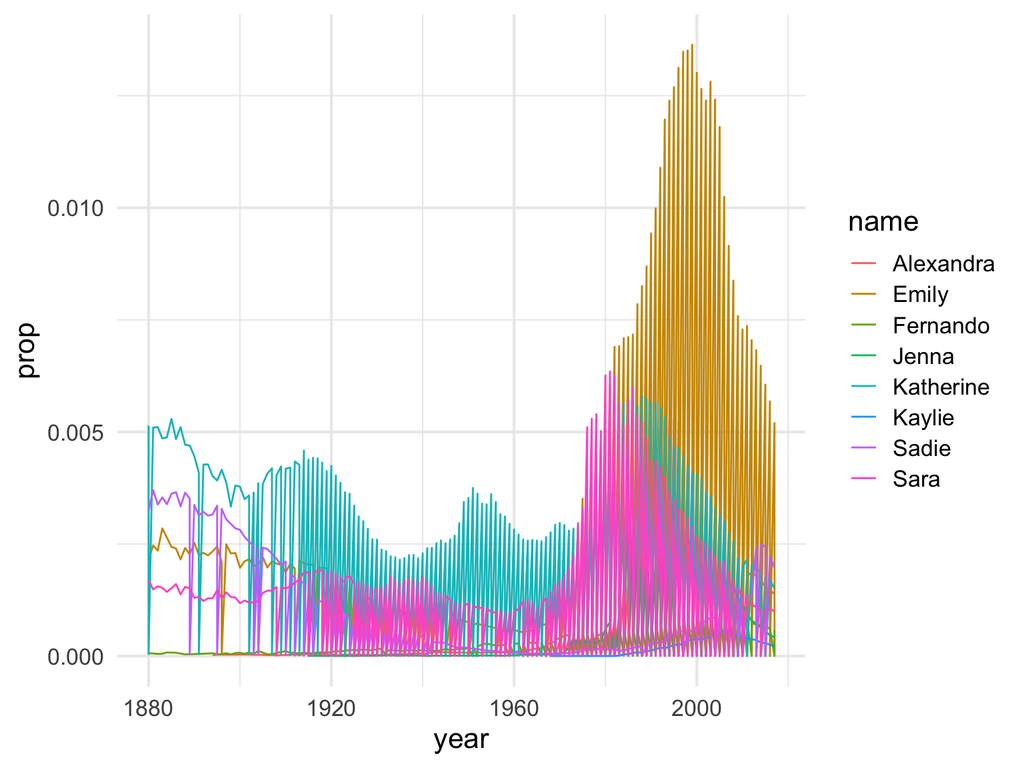

Why is this happening? *(Hint: inspect the data for “Emily” in the year 2000)*

#### **Problem 2:**

Modify the filter statement above to obtain a data set of names for this class that does not have this problem. Use the exact same ggplot code as above to verify that the problem is gone. Recall that the “or” operator in R is `|` and the “and” operator in R is `&`.

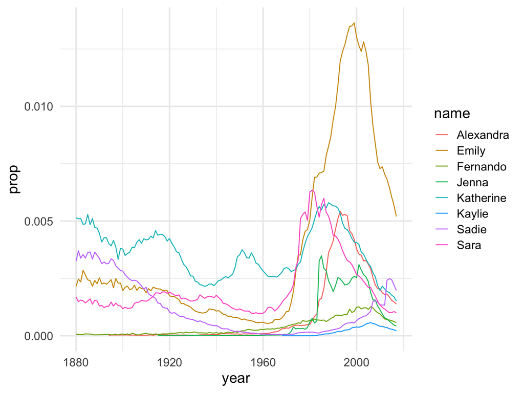

Answer the following question:

- Describe (in words) the logic of this modified `filter()` statement (i.e., what rows are retained in the data set?). How did this solve our problem?

#### **Problem 3:**

If we’re interested trends for each name over time rather than relative popularity, the previous graph is of limited use In particular, the popularity of “Emily” during the late 20th and early 21st century makes it hard to see the trends over time for some of the less-common names.

Show the same data as small multiples with the following characteristics:

- Each name has in its own separate small panel.
- Each small panel has its own y-axis that is scaled to the popularity of the name.
- Remove color so that all lines are simply black.

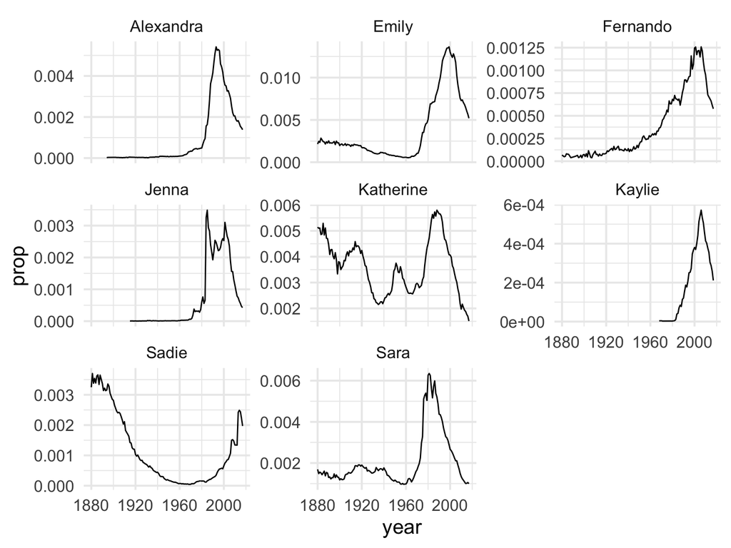

#### **Problem 4:**

We can emphasize the temporal trends more effectively by filling the area under each curve. We can do this using `geom_ribbon()`. Try to add a ribbon to the previous plot with 50% transparency (`alpha = 0.5`). To get the aesthetic mappings right, it may be helpful to read to the [help page]](https://ggplot2.tidyverse.org/reference/geom_ribbon.html) for `geom_ribbon()`.

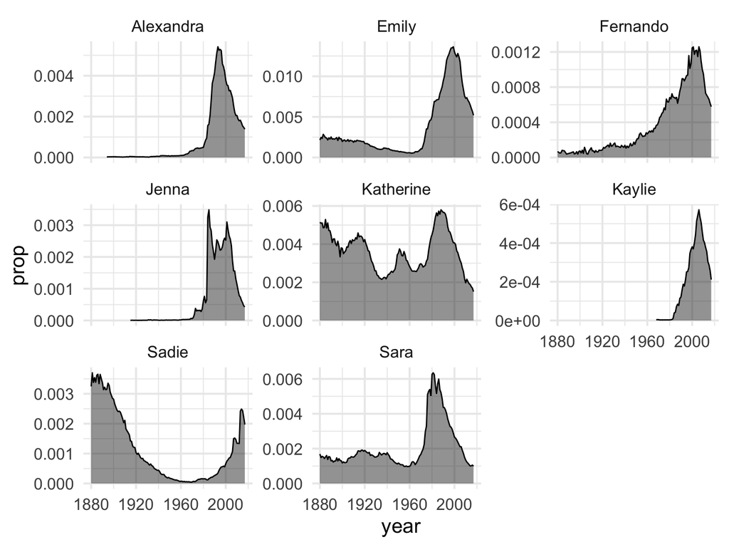

#### **Problem 5:**

Although color would be redundant here, let’s bring it back in to get some practice with ribbons. Try mapping fill and/or color to `name` to get the plot to look exactly like the one I made in the solutions file. *Note in particular that there is no solid outline on the sides and bottom!* You can try doing this globally or in the `geom` functions, but not all configurations will produce the desired effect. The color/fill legend is pointless, so let’s turn it off by adding this line to the plot: `guides(color = "none", fill = "none")`.

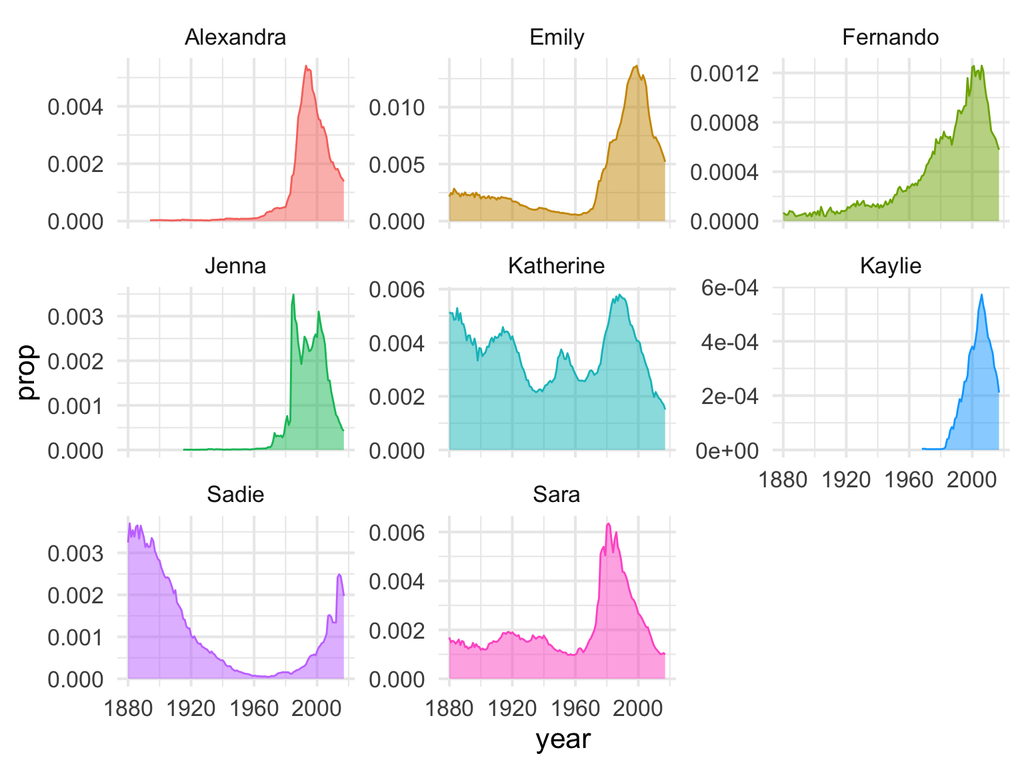

#### **Problem 6:**

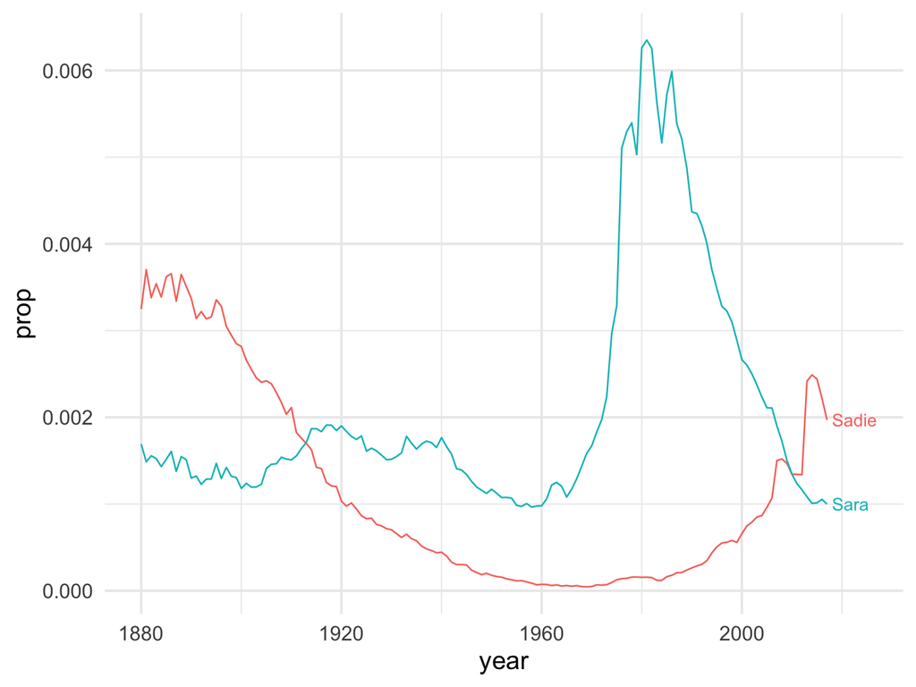

Answer the following questions about this code and its plot:

- Describe the data set used for the `geom_text()` function. How does the modified filter statement accomplish what we need? How many rows does this subset have?
- What code here is keeping the text from overlapping with the line?
- Try deleting `hjust = 0` (the default is `hjust = 0.5`), or replacing it with `hjust = 1`. What does this option do?
- View the help file for `expand_limits()` and describe how it improves our plot.

#### **Problem 7:**

There’s another similar geom called `geom_path()`. To see how it differs from `geom_line()`, we’re going to sort our data set by the column `prop`. This is our first introduction to a lovely `dplyr` function called `arrange()`. Like other tidyverse functions that you have encountered, the function takes a data set as its first argument. After that, we simply give it the column that we want to sort by.

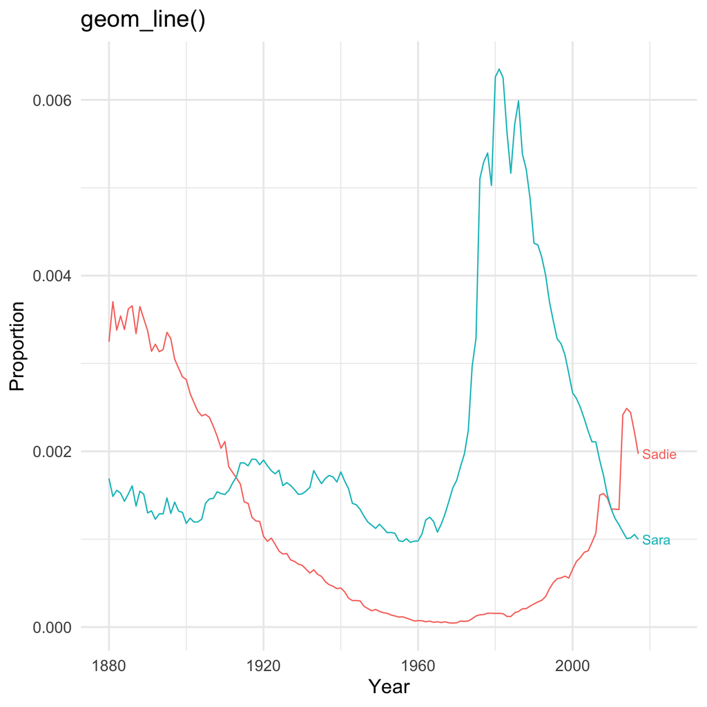

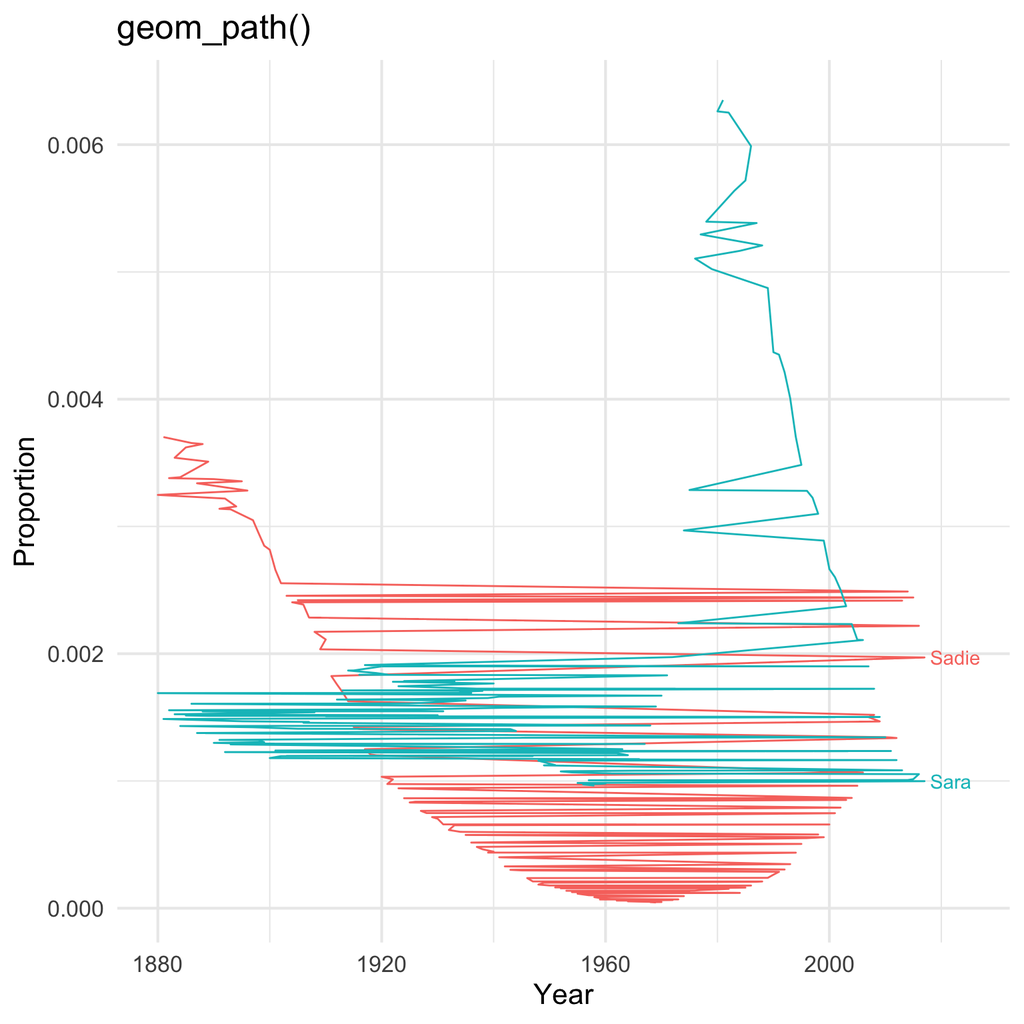

Answer the following questions about this code and its plot:

- Describe the difference between `geom_line()` and `geom_path()`.
- If you were plotting an animal’s GPS location data on x and y axes to show its movement, which geom would produce the right plot?

#### **Problem 8:**

Finally, let’s practice adding annotations to plots. An annotation is graphical element, like a point, line, box, or text label, that is added to a plot but is not part of your data set. Annotations can be added using the `annotate()` function. Note that writing `\n` in the text forces a line break.

We’re going to plot the popularity over time of the name Lionel for boys, and annotate some of interesting features with both rectangles and text. Here’s a template:

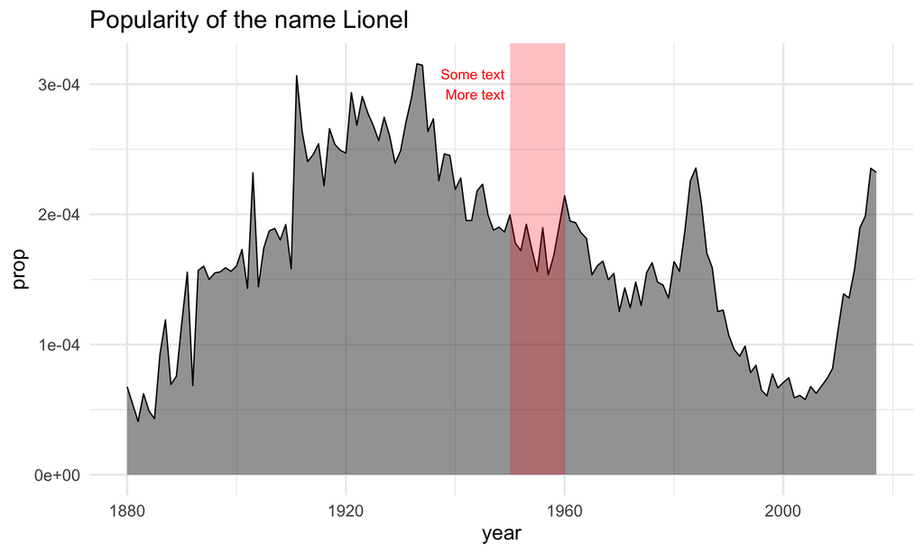

Note that putting `\n` in the label creates a line break. Using this template, highlight and label the following notable periods in the history of the name Lionel.

- 1931 – 1936: “Peak popularity in early 30s” (I used color “seagreen3”)
- 1982 – 1986: “Lionel Richie’s 3 best-selling albums” (I used color “coral”)
- 2004 – 2017: “Lionel Messi’s career with FC Barcelona” (I used color “skyblue2”)

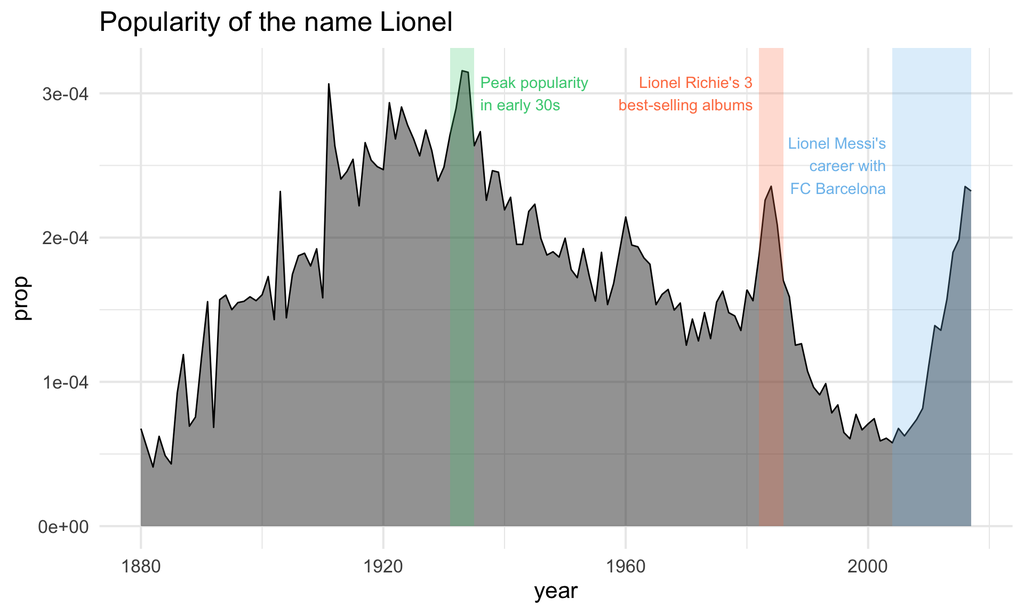